# Lab 5

Bernard Fay, Github: bj99fay; Chase Weida, GitHub: cweida

4/13/2020

## Load the data

```r
accident <- read.csv("https://raw.githubusercontent.com/xdaiISU/ds202materials/master/hwlabs/fars2017/accident.csv", stringsAsFactors = FALSE)
person <- read.csv("https://raw.githubusercontent.com/xdaiISU/ds202materials/master/hwlabs/fars2017/person.csv", stringsAsFactors = FALSE)
```

## 1

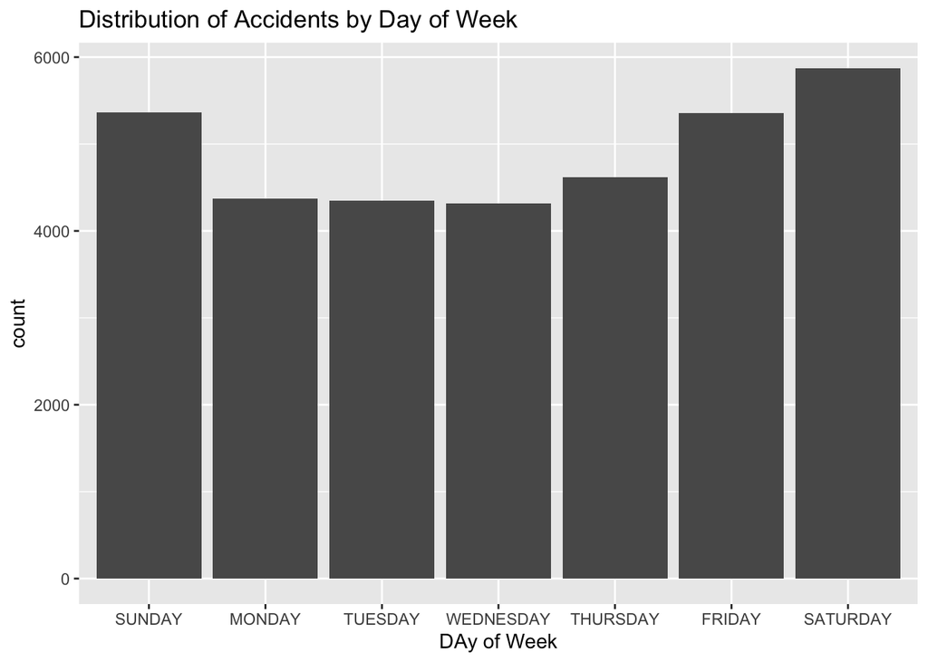

```r
day.dist <- accident %>%
  mutate(DAY_WEEK_NAME=recode(as.factor(DAY_WEEK), "1" = "SUNDAY", "2" = "MONDAY", "3" = "TUESDAY", "4" = "WEDNESDAY",
         "5" = "THURSDAY", "6" = "FRIDAY", "7" = "SATURDAY", "9" = "UNKNOWN")) %>%
  group_by(DAY_WEEK_NAME)
day.dist %>% ggplot(aes(x=DAY_WEEK_NAME)) + geom_bar() + labs(x = "DAy of Week", title = "Distribution of Accidents by Day of Week")
```

Accidents happen more often on Fridays, Saturdays, and Sundays. These are days that people don’t typically work, so this could be a cause of the higher number of accidents.

## 2

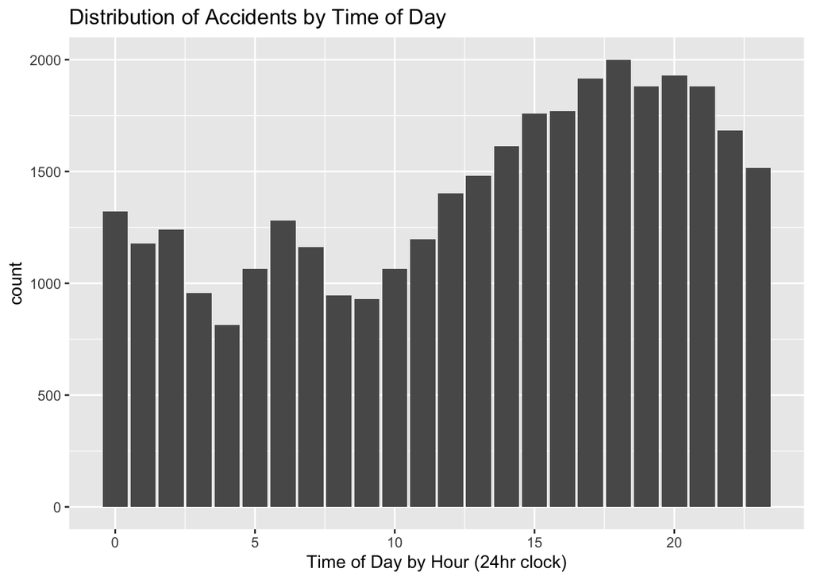

```r
time.dist <- accident %>%
  filter(HOUR < 24) %>%
  group_by(HOUR)
time.dist %>% ggplot(aes(x=HOUR)) + geom_bar() + labs(x = "Time of Day by Hour (24hr clock)", title = "Distribution of Accidents by Time of Day")
```

Accidents tend to happen in the late afternoon/evening. This is the time most people head home from work, so this could be a potential cause of the increase i accidents.

## 3

```r
drunk <- accident %>%
  mutate(DRUNK = ifelse(DRUNK_DR > 0, "Yes", "No")) %>%
  group_by(DRUNK)

drunk %>% filter(DRUNK == "Yes") %>% count() %>% rename("Drunk driving accidents" = "n")
```

```
## # A tibble: 1 x 2
## # Groups:   DRUNK [1]
##   DRUNK `Drunk driving accidents`
##   <chr>                     <int>
## 1 Yes                        8769
```

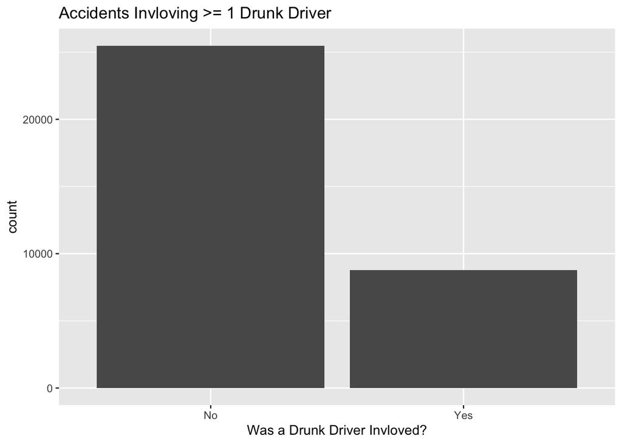

```r
drunk %>% ggplot(aes(x=DRUNK)) + geom_bar() + labs(x = "Was a Drunk Driver Invloved?", title = "Accidents Invloving >= 1 Drunk Driver")
```

There were 8769 accidents involving at least one drunk driver. There are around three times as many accidents not involving a drunk driver, so drunk driving account fro around 1/4 of all accidents.

## 4

```r
person <- person %>%
  filter(PER_TYP == 1)
head(person)
```

```
##   STATE ST_CASE VE_FORMS VEH_NO PER_NO STR_VEH COUNTY DAY MONTH HOUR MINUTE
## 1     1   10001        1      1      1       0     73  19     2   23     35
## 2     1   10002        1      1      1       0     89  14     2   14     59
## 3     1   10003        3      1      1       0    101  31     1   20     31
## 4     1   10003        3      2      1       0    101  31     1   20     31
## 5     1   10003        3      3      1       0    101  31     1   20     31
## 6     1   10004        1      1      1       0     73   1     1   16     55
##   RUR_URB FUNC_SYS HARM_EV MAN_COLL SCH_BUS MAKE MAK_MOD BODY_TYP MOD_YEAR
## 1       2        1      38        0       0   20   20421       15     2004
## 2       2        1       1        0       0   37   37402       14     2005
## 3       2        1      12        1       0   82   82881       66     2007
## 4       2        1      12        1       0    2    2404       14     2003
## 5       2        1      12        1       0   84   84884       66     2015
## 6       2        4      30        0       0   30   30046        4     2014
##   TOW_VEH SPEC_USE EMER_USE ROLLOVER IMPACT1 FIRE_EXP AGE SEX PER_TYP INJ_SEV
```

[output cut: 41 more lines]

## 5

```r
accPer <- accident %>% inner_join(person, by = c('ST_CASE', 'STATE', 'COUNTY'))
```

## 6

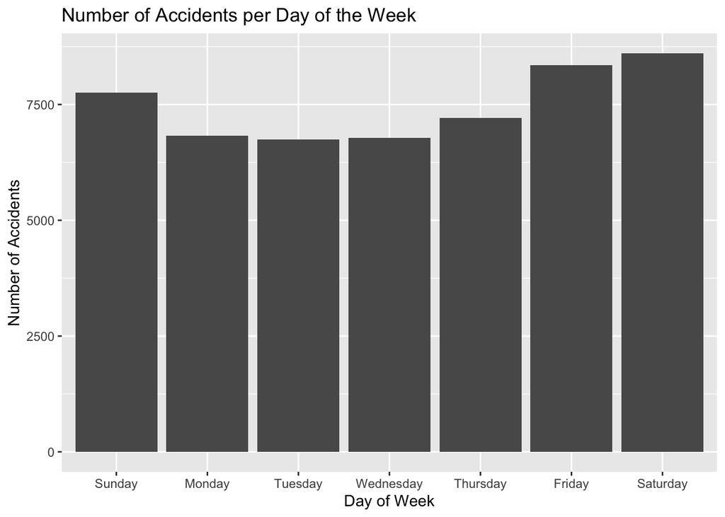

```r
accPer %>% group_by(DAY_WEEK) %>% tally() %>% ggplot(aes(x = factor(DAY_WEEK), y = n)) + geom_bar(stat = 'identity') +
  ggtitle("Number of Accidents per Day of the Week") + xlab('Day of Week') +
  ylab("Number of Accidents") +
  scale_x_discrete(breaks = c("1", "2", "3", "4", "5", "6", "7"), labels = c("Sunday", "Monday", "Tuesday", "Wednesday", "Thursday", "Friday", "Saturday"))
```

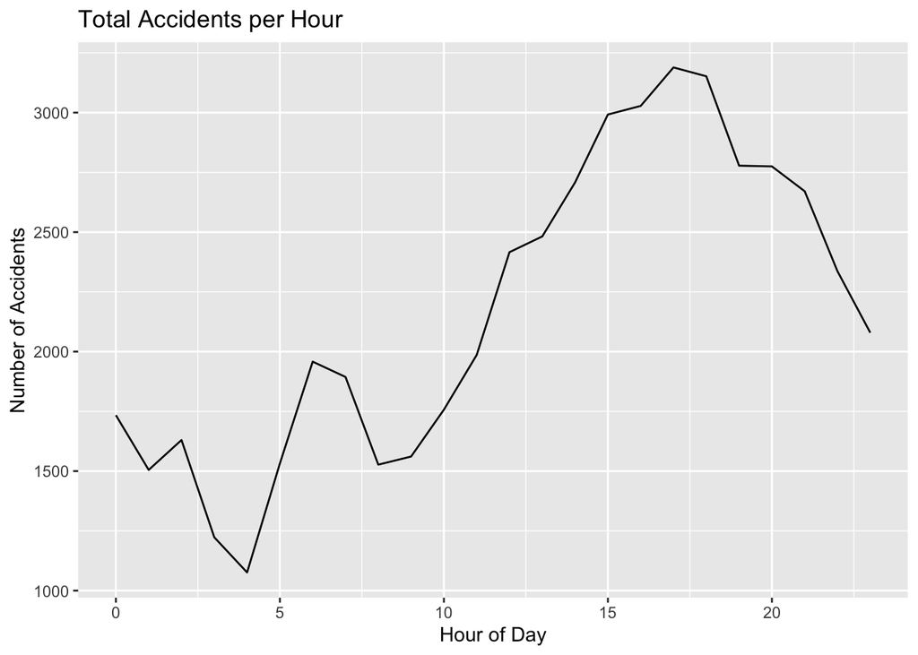

```r
accPer %>% group_by(HOUR.x) %>% tally() %>% filter(HOUR.x != 99) %>% ggplot(aes(x = HOUR.x, y = n)) + geom_line() + ggtitle("Total Accidents per Hour") +
  xlab("Hour of Day") + ylab("Number of Accidents")
```

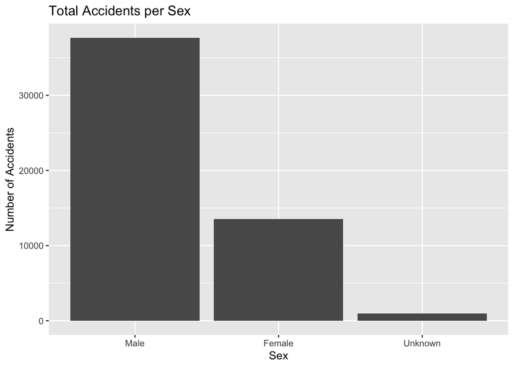

```r
accPer %>% group_by(SEX) %>% tally() %>% filter(n > 900) %>% ggplot(aes(x = factor(SEX), y = n)) + geom_bar(stat = 'identity')+
  ggtitle("Total Accidents per Sex") + xlab('Sex') + ylab("Number of Accidents") +
  scale_x_discrete(breaks = c('1','2','9'), labels = c('Male', "Female", "Unknown"))
```

As seen above, accidents are heavily focused around the weekends. Specifically, Fridays, Saturdays, and Sundays feature higher rates of accidents. Drivers are also more prone to accidents in the late afternoon, mostly from 5pm to 7pm. This likely due to the large number of drivers getting off of work for the day and commuting home. Finally, we can see the vast majority of accidents involve male drivers.

## 7/8

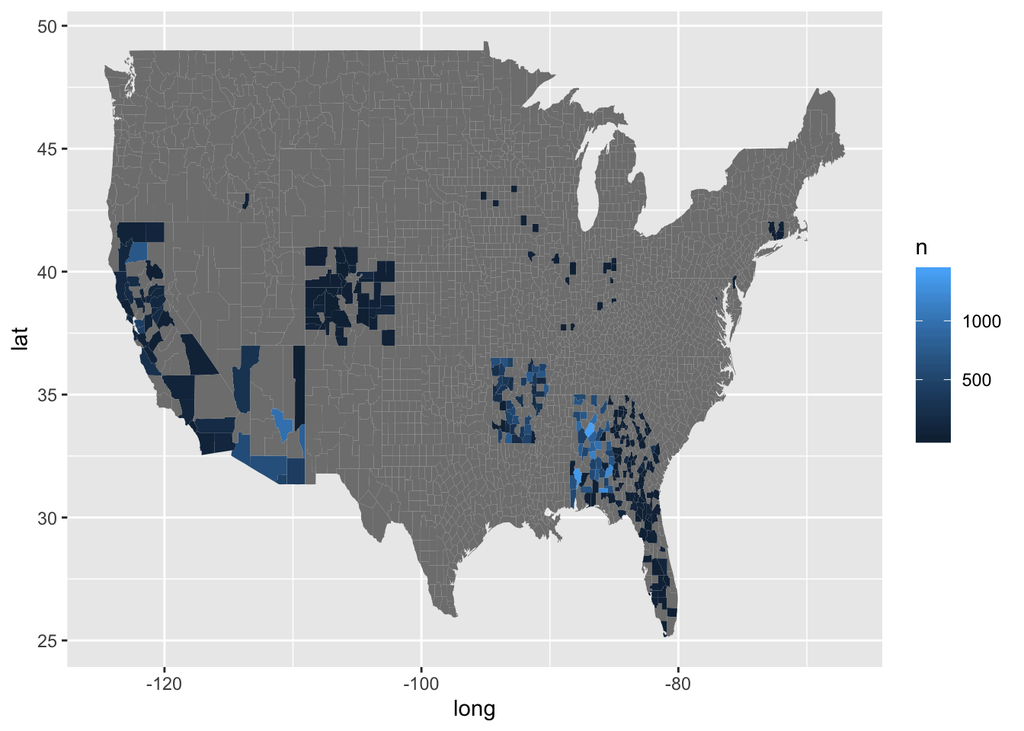

```r
county <- map_data("county")
countytally <- accPer %>% group_by(COUNTY) %>% tally()
colnames(countytally)[1] <- 'group'

finalSet <- county %>% left_join(countytally, by = 'group')
ggplot(finalSet, mapping = aes(x = long, y = lat, group = group, fill = n)) + geom_polygon()
```

## 9

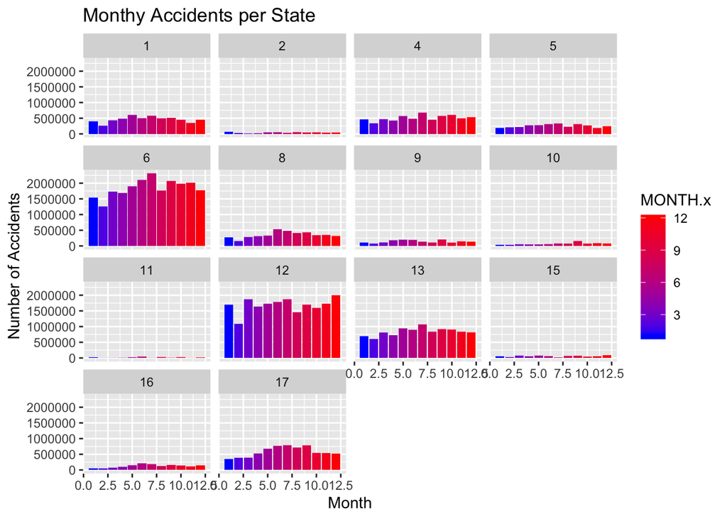

```r
monthTally <- accPer %>% group_by(MONTH.x) %>% tally()

accPer <- accPer %>% right_join(monthTally, by = "MONTH.x")

accPer1 <- accPer %>% filter(STATE < 18)
accPer2 <- accPer %>% filter(STATE < 36, STATE >= 18)
accPer3 <- accPer %>% filter(STATE < 51, STATE >= 36)


ggplot(accPer1, mapping = aes(x = MONTH.x, y = n, fill = MONTH.x)) +
  geom_bar(stat = 'identity') +
  facet_wrap("STATE")+
  scale_fill_gradient(low = 'blue', high = 'red') + ggtitle("Monthy Accidents per State")+
  xlab("Month") + ylab("Number of Accidents")
```

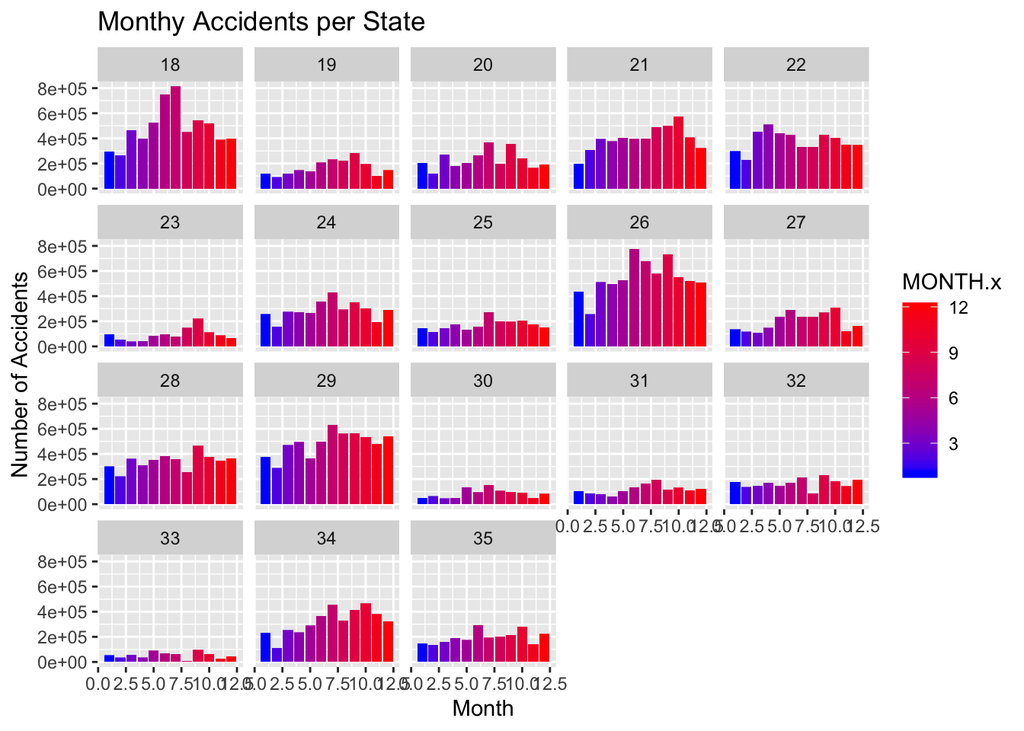

```r
ggplot(accPer2, mapping = aes(x = MONTH.x, y = n, fill = MONTH.x)) +
  geom_bar(stat = 'identity') +
  facet_wrap("STATE")+
  scale_fill_gradient(low = 'blue', high = 'red') + ggtitle("Monthy Accidents per State")+
  xlab("Month") + ylab("Number of Accidents")
```

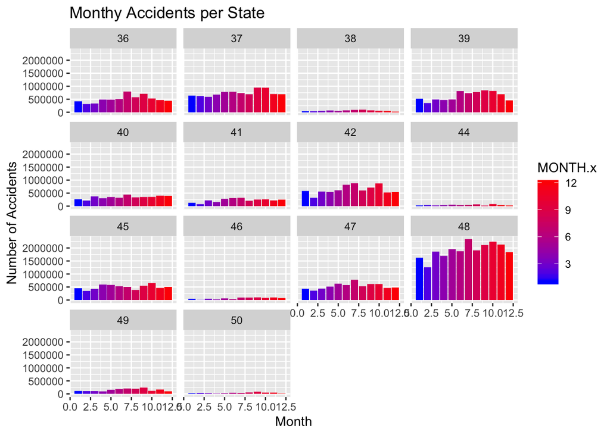

```r
ggplot(accPer3, mapping = aes(x = MONTH.x, y = n, fill = MONTH.x)) +
  geom_bar(stat = 'identity') +
  facet_wrap("STATE")+
  scale_fill_gradient(low = 'blue', high = 'red') + ggtitle("Monthy Accidents per State")+
  xlab("Month") + ylab("Number of Accidents")
```